# MRF PROJEKT

Tymoteusz Hanusiak Peter Jurus

2025-12-20

# **PROJEKT CZESC 1**

# Czyszczenie danych

```r
library(knitr)
opts_chunk$set(message = FALSE, warning = FALSE)
```

```r
library(readr)
library(dplyr)
library(lubridate)
library(stringr)
library(purrr)
library(tidyr)
library(moments)
library(ggplot2)
library(rugarch)


# pierwsza funkcja czyszczaca wsstepnie dane z obydwu plikow

clean_intraday_data <- function(path) {

  df <- read.csv2(path, stringsAsFactors = FALSE)

  df$daty <- as.Date(as.character(df$daty), format = "%Y%m%d")

  godz_char <- sprintf("%06d", as.integer(df$godz))

  df$datetime <- as.POSIXct(
    paste(df$daty,paste0(

      substr(godz_char, 1, 2), ":",

      substr(godz_char, 3, 4), ":",

      substr(godz_char, 5, 6)
      )
    ),
    format = "%Y-%m-%d %H:%M:%S", # tz
  )

  df$cena <- as.numeric(df$cena)
  df$vol  <- as.numeric(df$vol)

  df <- df[ format(df$datetime, "%H:%M:%S") >= "09:00:00" & format(df$datetime, "%H:%M:%S") <= "17:05:00",]

  df <- df[order(df$datetime), ]

  end_date  <- seq(min(df$daty), by = "6 months", length.out = 2)[2]

  df <- df[df$daty < end_date, ]

  df$godz <- NULL

  return(df)
}



dane_spolkaI <- clean_intraday_data("spolkaI.csv")
dane_spolkaJ <-  clean_intraday_data("spolkaJ.csv")

head(dane_spolkaI)
```

```
        daty  cena vol            datetime
1 2018-01-03 101.4  27 2018-01-03 09:00:00
2 2018-01-03 101.4   1 2018-01-03 09:00:00
3 2018-01-03 101.4  56 2018-01-03 09:00:00
4 2018-01-03 101.4   1 2018-01-03 09:00:00
5 2018-01-03 101.4   2 2018-01-03 09:00:00
6 2018-01-03 101.4  10 2018-01-03 09:00:00
```

```r
head(dane_spolkaJ)
```

```
        daty cena  vol            datetime
1 2018-01-03 46.3   45 2018-01-03 09:00:00
2 2018-01-03 46.3    1 2018-01-03 09:00:00
3 2018-01-03 46.3 2000 2018-01-03 09:00:00
4 2018-01-03 46.3  843 2018-01-03 09:00:00
5 2018-01-03 46.3   22 2018-01-03 09:00:00
6 2018-01-03 46.3   24 2018-01-03 09:00:00
```

```r
colSums(is.na(dane_spolkaI))
```

```
    daty     cena      vol datetime
       0        0        0        0
```

```r
colSums(is.na(dane_spolkaJ))
```

```
    daty     cena      vol datetime
       0        0        0        0
```

```r
tail(dane_spolkaI)
```

```
             daty cena vol            datetime
586657 2018-07-02 76.4 193 2018-07-02 17:00:01
586658 2018-07-02 76.4 155 2018-07-02 17:00:01
586659 2018-07-02 76.4  50 2018-07-02 17:00:01
586660 2018-07-02 76.4 100 2018-07-02 17:00:01
586661 2018-07-02 76.4 232 2018-07-02 17:00:01
586662 2018-07-02 76.4 100 2018-07-02 17:00:01
```

```r
tail(dane_spolkaJ)
```

```
             daty cena    vol            datetime
514015 2018-07-02   39    116 2018-07-02 17:00:01
514016 2018-07-02   39   1959 2018-07-02 17:00:01
514017 2018-07-02   39   3433 2018-07-02 17:00:01
514018 2018-07-02   39    269 2018-07-02 17:00:01
514019 2018-07-02   39     30 2018-07-02 17:01:32
514020 2018-07-02   39 300000 2018-07-02 17:02:31
```

```r
range(format(dane_spolkaI$datetime, "%H:%M:%S"))
```

```
[1] "09:00:00" "17:05:00"
```

```r
range(format(dane_spolkaJ$datetime, "%H:%M:%S"))
```

```
[1] "09:00:00" "17:04:59"
```

# Funkcje do liczenia statystyk opisowych

```r
intraday_descriptive_stats <- function(df) {

  price_stats <- c(
    mean   = mean(df$cena),
    sd     = sd(df$cena),
    median = median(df$cena),
    q75    = quantile(df$cena, 0.75)
  )

  volume_stats <- c(
    mean   = mean(df$vol),
    sd     = sd(df$vol),
    median = median(df$vol),
    q75    = quantile(df$vol, 0.75)
  )

  # zeby nie bralo roznic miedyz trasakcjami w tym samym czasie
  time_diff <- as.numeric(diff(df$datetime), units = "secs")
  time_diff <- time_diff[time_diff > 0]

  intertrade_time_stats <- c(
    mean   = mean(time_diff),
    sd     = sd(time_diff),
    median = median(time_diff),
    q75    = quantile(time_diff, 0.75)
  )

  trades_per_day <- table(as.Date(df$datetime)) # unique dates

  trades_stats <- c(
    mean   = mean(trades_per_day),
    sd     = sd(trades_per_day),
    median = median(trades_per_day),
    q75    = quantile(trades_per_day, 0.75)
  )

  daily_agg <- aggregate(
    cbind(vol, value = df$vol * df$cena) ~ as.Date(df$datetime), # dzienny wolumen i obrot
    data = df,
    sum
  )

  daily_volume_stats <- c(
    mean   = mean(daily_agg$vol),
    sd     = sd(daily_agg$vol),
    median = median(daily_agg$vol),
    q75    = quantile(daily_agg$vol, 0.75)
  )

  daily_value_stats <- c(
    mean   = mean(daily_agg$value),
    sd     = sd(daily_agg$value),
    median = median(daily_agg$value, 0.75),
    q75    = quantile(daily_agg$value, 0.75)
  )

  list(
    price_transaction   = price_stats,
    volume_transaction   = volume_stats,
    intertrade_time_sec = intertrade_time_stats,
    trades_per_session    = trades_stats,
    daily_volume        = daily_volume_stats,
    daily_turnover_value  = daily_value_stats
  )
}
```

```r
stats_spolka1 <- intraday_descriptive_stats(dane_spolkaI)

stats_spolka2 <- intraday_descriptive_stats(dane_spolkaJ)
```

```r
stats_spolka1
```

```
$price_transaction
     mean        sd    median   q75.75%
87.526020  8.383156 86.060000 91.840000

$volume_transaction
     mean        sd    median   q75.75%
 176.2012 1151.7381  100.0000  179.0000

$intertrade_time_sec
      mean         sd     median    q75.75%
  73.97038 2970.25759    5.00000   18.00000

$trades_per_session
    mean       sd   median  q75.75%
4731.129 2376.567 4197.500 5877.750

$daily_volume
    mean       sd   median  q75.75%
833630.6 470223.8 764210.5 960162.2

$daily_turnover_value
    mean       sd   median  q75.75%
72882637 42232505 64993388 86751665
```

```r
stats_spolka2
```

```
$price_transaction
     mean        sd    median   q75.75%
43.825423  2.464415 43.560000 45.570000

$volume_transaction
    mean       sd   median  q75.75%
 526.480 4148.518  260.000  500.000

$intertrade_time_sec
      mean         sd     median    q75.75%
  81.22892 3112.54886    5.00000   20.00000

$trades_per_session
    mean       sd   median  q75.75%
4145.306 1763.457 3814.500 4893.500

$daily_volume
   mean      sd  median q75.75%
2182421 1191332 1908495 2568050

$daily_turnover_value
     mean        sd    median   q75.75%
 95552981  50330520  83280051 113683561
```

## statystyki opisowe interpretacja

- **turnover to wartosc obrotu**
- W obu spółkach rozkład cen pojedynczych transakcji jest podobny mediana jest zbliżona do średniej, co wskazuje na brak outlierów (ktore są bardzo daleko od reszty).
- Spolka 2 charakteryzuje się wyższym przeciętnym wolumenem pojedynczej transakcji oraz większą różnicą pomiędzy średnią a medianą wolumenu, co świadczy o sporadycznych dużych transakcjach.
- Zdecydowanie wyższe odchylenie standardowe wolumenu w Spółce 2 wskazuje na większą zmienność wielkości transakcji, co może być związane z np zleceniami pakietowymi podczas np otwarcia i zamkniecia.
- Obie spółki charakteryzują się porównywalną liczbą transakcji w trakcie jednej sesji, jednak spolka 1 jest przeciętnie częściej tradeowana, co potwierdzają krótsze odstępy czasowe pomiędzy kolejnymi trade-ami jak i statystyki dotyczace kolumny trades_per_session.
- Spółka 2 ma wyższy dzienny sredni wolumen oraz wyższą dzienną wartość obrotu, natomiast jest tez rzadziej tradeowana niz spolka 1 , co swiadczy ze w spolce drugiej jest wieksza ekspozycja duzych inwestorow np Fundusze, Hedge-Fundy a w pierwszej wieksza koncentracja retail inwestorow.

# agregacja danych do 1 sekundy (srednia wazona po wolumenie)

```r
# cena jako srednia wazona wolumenem a wolumen jako suma.
aggregate_to_1s <- function(df) {

  # sekunda
  df$sec_time <- as.POSIXct( floor(as.numeric(df$datetime)),origin = "1970-01-01")

   agg_vol <- aggregate(
    vol ~ sec_time,
    data = df,
    sum
  )

   agg_pv <- aggregate(
    cena * vol ~ sec_time,
    data = df,
    sum
  )

  out <- data.frame(
    datetime = agg_vol$sec_time,
    price    = agg_pv[, 2] / agg_vol$vol, # srednia wazona wolumenem
    volume   = agg_vol$vol # suma wolumenu
  )

   out$return <- c(NA, diff(out$price) / head(out$price, -1))

  return(out)
}
```

```r
returns_1s_spolkaJ <- aggregate_to_1s(dane_spolkaJ) # dane_spolkaI

head(returns_1s_spolkaJ)
```

```
             datetime    price volume        return
1 2018-01-03 09:00:00 46.30000   5569            NA
2 2018-01-03 09:00:02 46.44000    871  0.0030237581
3 2018-01-03 09:00:07 46.44000    393  0.0000000000
4 2018-01-03 09:00:16 46.35000    651 -0.0019379845
5 2018-01-03 09:00:24 46.42688   1524  0.0016586114
6 2018-01-03 09:00:26 46.46000    389  0.0007134522
```

```r
returns_1s_spolkaI <-aggregate_to_1s(dane_spolkaI) # dane_spolkaI

head(returns_1s_spolkaI)
```

```
             datetime    price volume        return
1 2018-01-03 09:00:00 101.4000    374            NA
2 2018-01-03 09:01:01 101.4000     48  2.802930e-16
3 2018-01-03 09:01:21 101.4000    100 -1.401465e-16
4 2018-01-03 09:01:23 101.4472    352  4.650798e-04
5 2018-01-03 09:01:34 101.4000     75 -4.648636e-04
6 2018-01-03 09:01:46 101.5682    471  1.658312e-03
```

# kurtoza autocorr i skosnosc

```r
analyze_returns_distribution <- function(df_I, df_J) {

  r_I <- df_I$return[!is.na(df_I$return)]
  r_J <- df_J$return[!is.na(df_J$return)]

  stats <- data.frame(Spolka = c("I", "J"),

  Skosnosc = c(skewness(r_I),skewness(r_J)),

  Kurtoza = c(kurtosis(r_I),kurtosis(r_J))

  )

  return(stats)
}
```

## acf ploty

```r
plot_acf_no_lag0 <- function(returns, max_lag = 100) {


  acf_obj <- acf(returns[!is.na(returns)], lag.max = max_lag, plot = TRUE,main='autokorelacja zwrotow')


 }
```

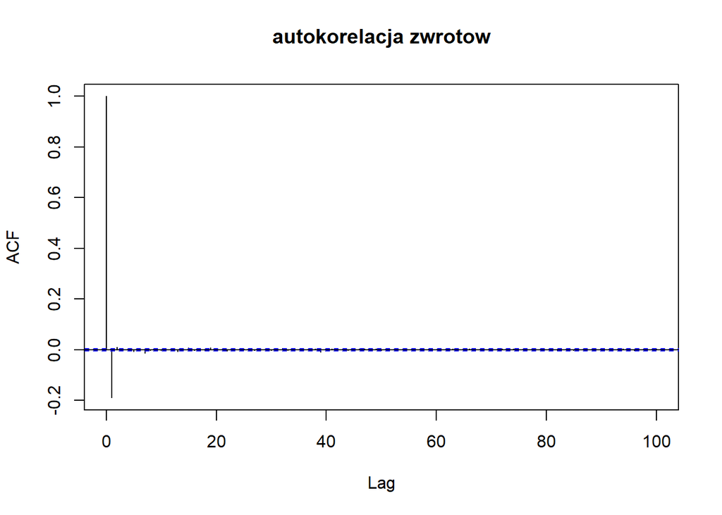

```r
plot_acf_no_lag0(returns_1s_spolkaI$return)
```

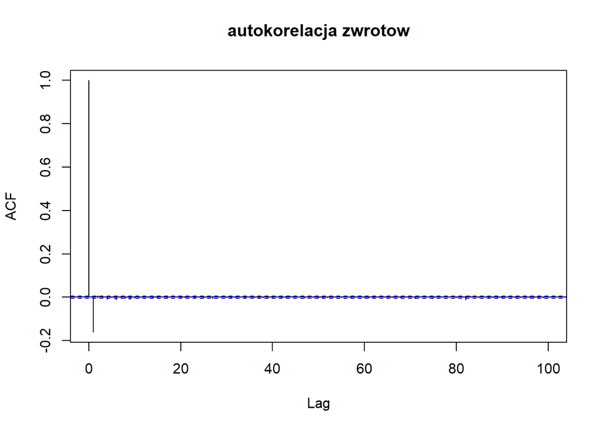

```r
plot_acf_no_lag0(returns_1s_spolkaJ$return)
```

```r
analyze_returns_distribution(
  returns_1s_spolkaI,
  returns_1s_spolkaJ
)
```

```
  Spolka  Skosnosc  Kurtoza
1      I -1.596054 263.1874
2      J -1.906608 166.2736
```

## Interpretacja

- Kurtoza ekspodowala az do ogromnych wartosci, co swiadczy o ogromnym odstepstwie od rozkladu normalnego , i o grubych ogonach w rozkladzie.
- Rozkladu zwrotow obydwu spolek sa silnie lewoskośne co oznacze ze ujemne zwroty sa bardziej ekstremalne niz dodatnie a takze lewy ogon rozkladu jest dluzszy niz prawy
- Zwroty nie wykazują istotnej dodatniej autokorelacji, co jest zgodne z typowymi własnościami danych intraday, Jedynie autkorelacja pierwszego rzędu ujemna jest stastystycznie istotna.

# ANALIZA DANYCH 5-MINUTOWYCH

```r
head(returns_1s_spolkaI)
```

```
             datetime    price volume        return
1 2018-01-03 09:00:00 101.4000    374            NA
2 2018-01-03 09:01:01 101.4000     48  2.802930e-16
3 2018-01-03 09:01:21 101.4000    100 -1.401465e-16
4 2018-01-03 09:01:23 101.4472    352  4.650798e-04
5 2018-01-03 09:01:34 101.4000     75 -4.648636e-04
6 2018-01-03 09:01:46 101.5682    471  1.658312e-03
```

```r
head(returns_1s_spolkaJ)
```

```
             datetime    price volume        return
1 2018-01-03 09:00:00 46.30000   5569            NA
2 2018-01-03 09:00:02 46.44000    871  0.0030237581
3 2018-01-03 09:00:07 46.44000    393  0.0000000000
4 2018-01-03 09:00:16 46.35000    651 -0.0019379845
5 2018-01-03 09:00:24 46.42688   1524  0.0016586114
6 2018-01-03 09:00:26 46.46000    389  0.0007134522
```

## opis STOPY ZWROTU LOG 5 MIN

- Bierzemy ostatnia obserwacje ktora jest ponizej 5 min np 9:04:49 wybierzemy jesli nastepna jest np 9:05:02

```r
compute_5min_intraday_returns <- function(df_1s) {

  df_1s$time_5min <- as.POSIXct(floor(as.numeric(df_1s$datetime) / 300) * 300, origin = "1970-01-01") # time division on 5 min brackets

  df_5min <- aggregate(
    price ~ time_5min,
    data = df_1s,
    FUN = tail,
    1
  )

  colnames(df_5min) <- c("datetime", "price")

  df_5min$return_log <- c(NA, diff(log(df_5min$price))) # liczenie log ret

  day <- as.Date(df_5min$datetime)

  # usuwanie overnight returns
  overnight <- day != dplyr::lag(day) # na wypadek problemow z ta sama zmienna przypisana juz do nazwy day direct import
  df_5min$return_log[overnight] <- NA

  df_5min <- df_5min[!is.na(df_5min$return_log), ]

  return(df_5min)
}
```

```r
returns_5min_spolkaI <- compute_5min_intraday_returns(returns_1s_spolkaI)
returns_5min_spolkaJ <- compute_5min_intraday_returns(returns_1s_spolkaJ)
```

```r
head(returns_5min_spolkaI,10)
```

```
              datetime    price    return_log
2  2018-01-03 09:05:00 102.9000  0.0092751458
3  2018-01-03 09:10:00 102.9000  0.0000000000
4  2018-01-03 09:15:00 102.6000 -0.0029197101
5  2018-01-03 09:20:00 102.7000  0.0009741842
6  2018-01-03 09:25:00 102.9500  0.0024313165
7  2018-01-03 09:30:00 102.9000 -0.0004857906
8  2018-01-03 09:35:00 102.9758  0.0007359543
9  2018-01-03 09:40:00 102.7000 -0.0026814803
10 2018-01-03 09:45:00 102.9000  0.0019455259
11 2018-01-03 09:50:00 102.8000 -0.0009722898
```

```r
head(returns_5min_spolkaJ,10)
```

```
              datetime    price    return_log
2  2018-01-03 09:05:00 46.36000 -4.313134e-04
3  2018-01-03 09:10:00 46.05000 -6.709256e-03
4  2018-01-03 09:15:00 45.88000 -3.698470e-03
5  2018-01-03 09:20:00 45.97000  1.959718e-03
6  2018-01-03 09:25:00 45.98000  2.175095e-04
7  2018-01-03 09:30:00 45.95000 -6.526705e-04
8  2018-01-03 09:35:00 46.04000  1.956735e-03
9  2018-01-03 09:45:00 46.00000 -8.691874e-04
10 2018-01-03 09:50:00 45.94000 -1.305199e-03
11 2018-01-03 09:55:00 45.94212  4.609385e-05
```

## LICZENIE PRZEKROJOWEJ SREDNIEJ I BINNING

```r
prepare_5min_bins <- function(df_1s) {

  # helper function ktora liczy log zwroty agreguje do binow 5 minutowych liczy count tradeow , wolumen , cene .
  # liczy to dla calej dlugosci szeregu

  df_1s$time_5min <- as.POSIXct(
    floor(as.numeric(df_1s$datetime) / 300) * 300,
    origin = "1970-01-01",)

  price_5min <- aggregate(
    price ~ time_5min,
    data = df_1s,
    FUN = tail,
    1
  )

  n_trades <- aggregate(
    price ~ time_5min,
    data = df_1s,
    FUN = length
  )

  volume_5min <- aggregate(
    volume ~ time_5min,
    data = df_1s,
    FUN = sum
  )

  df <- merge(price_5min, n_trades, by = "time_5min")
  df <- merge(df, volume_5min, by = "time_5min")

  colnames(df) <- c("datetime", "price", "n_trades", "volume")

  df$return_log <- c(NA, diff(log(df$price)))

  day <- as.Date(df$datetime)

  df$return_log[day != dplyr::lag(day)] <- NA

  df <- df[!is.na(df$return_log), ] # na wyapdek nanow kore sie zdarza bo w maim funkcji ich nie usunelismy

  df$time_in_session <- format(df$datetime, "%H:%M")

  df
}
```

```r
compute_cs_intraday <- function(df_5min) {

  # podpunkt 2 czesc 1 funkcja do liczenia 3 wykresow log wolumen, srednie stopy i sredni count transakcji , wszystko na danych 5 min zagregowane do binow
  # agreguje dane w trakcie sesji

  aggregate(
    cbind( return_log, n_trades, log_volume = log(volume) ) ~ time_in_session,
    data = df_5min,
    FUN = base::mean,
    na.rm = TRUE
  )
}
```

```r
data_5min_I <- prepare_5min_bins(returns_1s_spolkaI)
data_5min_J <- prepare_5min_bins(returns_1s_spolkaJ)

cs_I <- compute_cs_intraday(data_5min_I)
cs_J <- compute_cs_intraday(data_5min_J)
```

```r
head(cs_I)
```

```
  time_in_session    return_log n_trades log_volume
1           09:05 -3.862093e-04 21.36585   8.483851
2           09:10 -2.951871e-04 19.58065   8.383779
3           09:15  8.358886e-05 22.79032   8.728127
4           09:20 -3.865560e-04 21.55645   8.576402
5           09:25  1.939737e-04 21.91935   8.663629
6           09:30  5.442256e-05 22.80645   8.705343
```

## **WYKRESY DLA SPOLKI I**

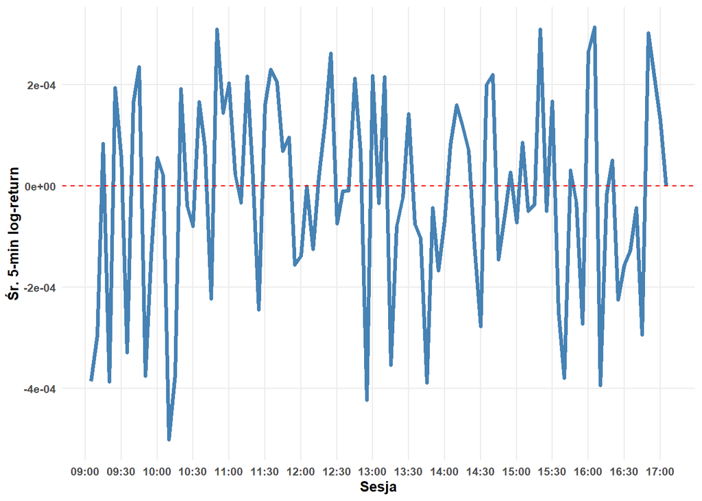

```r
cs_I$time_posix <- as.POSIXct(
  paste("1970-01-01", cs_I$time_in_session),
  format = "%Y-%m-%d %H:%M")


ggplot(cs_I, aes(x = time_posix, y = return_log)) +
  geom_line(color = "steelblue", linewidth = 1.4) +
  geom_hline(yintercept = 0, linetype = "dashed", color = "red") +
  scale_x_datetime(
    date_labels = "%H:%M",
    date_breaks = "30 min"
  ) +
  labs(
    x = "Sesja",
    y = "Śr. 5-min log-return"
  ) +
  theme_minimal(base_size = 10) +
  theme(
    panel.grid.minor = element_blank(),
    axis.title = element_text(face = "bold"),
    axis.text  = element_text(face = "bold")
  )
```

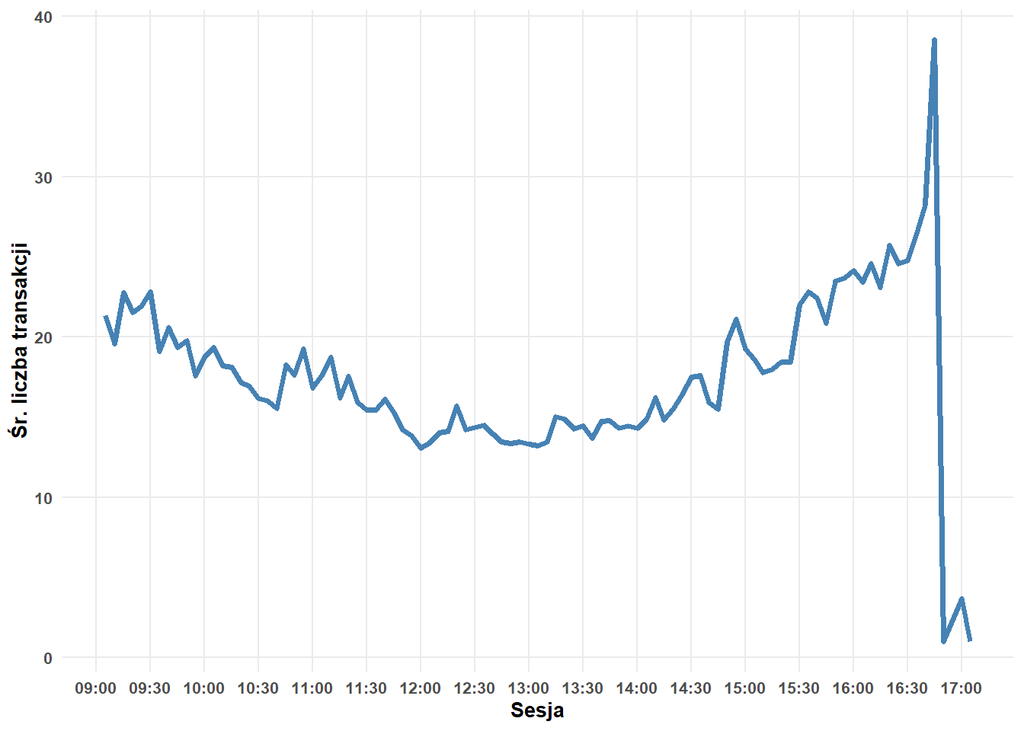

```r
ggplot(cs_I, aes(x = time_posix, y = n_trades)) +
  geom_line(color = "steelblue", linewidth = 1.4) +
  scale_x_datetime(
    date_labels = "%H:%M",
    date_breaks = "30 min"
  ) +
  labs(
    x = "Sesja",
    y = "Śr. liczba transakcji"
  ) +
  theme_minimal(10) +
  theme(
    panel.grid.minor = element_blank(),
    axis.title = element_text(face = "bold"),
    axis.text  = element_text(face = "bold")
  )
```

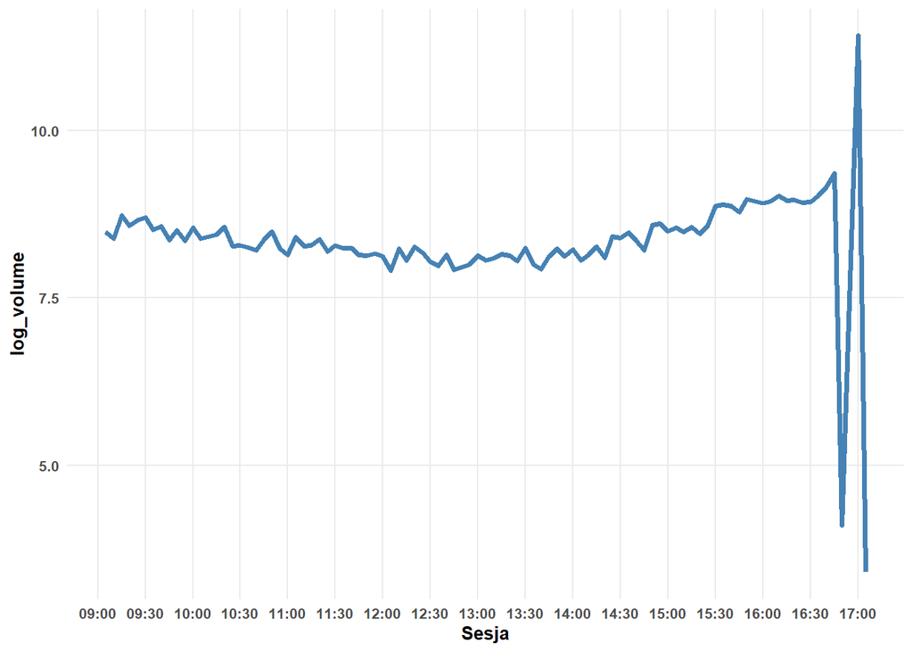

```r
ggplot(cs_I, aes(x = time_posix, y = log_volume)) +
  geom_line(color = "steelblue", linewidth = 1.4) +
  scale_x_datetime(
    date_labels = "%H:%M",
    date_breaks = "30 min"
  ) +
  labs(
    x = "Sesja",
  ) +
  theme_minimal(base_size = 10) +
  theme(
    panel.grid.minor = element_blank(),
    axis.title = element_text(face = "bold"),
    axis.text  = element_text(face = "bold")
  )
```

```r
compute_cs_mean_abs_returns <- function(df_5min) {

  df_5min$time_in_session <- format(df_5min$datetime, "%H:%M")

  aggregate(
    abs(return_log) ~ time_in_session,
    data = df_5min,
    FUN = base::mean,
   )
}
```

```r
cs_abs_I <- compute_cs_mean_abs_returns(returns_5min_spolkaI)
cs_abs_J <- compute_cs_mean_abs_returns(returns_5min_spolkaJ)
```

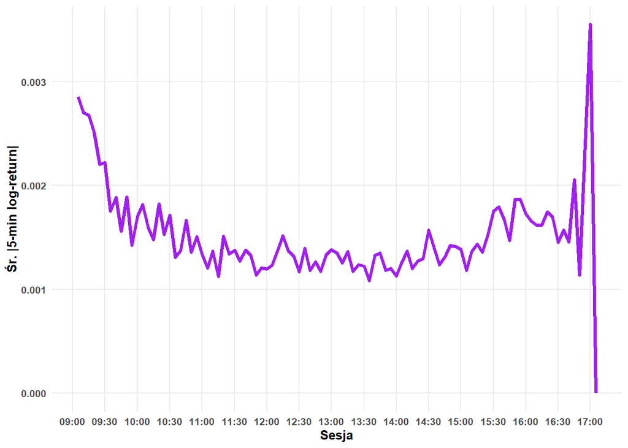

```r
cs_abs_I$time_posix <- as.POSIXct(
  paste("1970-01-01", cs_abs_I$time_in_session),
  format = "%Y-%m-%d %H:%M")


ggplot(cs_abs_I, aes(x = time_posix, y = `abs(return_log)`)) +
  geom_line(color = "purple", linewidth = 1.4) +
  scale_x_datetime(
    date_labels = "%H:%M",
    date_breaks = "30 min"
  ) +
  labs(
    x = "Sesja",
    y = "Śr. |5-min log-return|"
  ) +
  theme_minimal(base_size = 10) +
  theme(
    panel.grid.minor = element_blank(),
    axis.title = element_text(face = "bold"),
    axis.text  = element_text(face = "bold")
  )
```

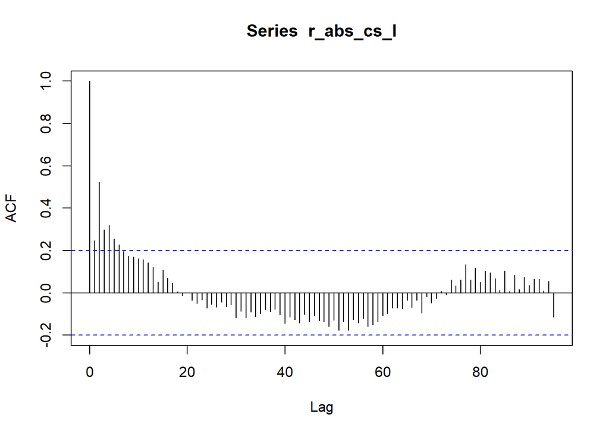

```r
r_abs_cs_I <- cs_abs_I$`abs(return_log)`[!is.na(cs_abs_I$`abs(return_log)`)]


acf_obj <- acf(r_abs_cs_I, lag.max = 300, plot = TRUE)
```

## interpretacja

- Sezonowość zmiennosci jest slaba i wraz ze wzrostem opóźnienia lagi sa statystycznie nieistotne poniewaz sa ponizej przedzialow ufnosci .
- Brak długiej pamieci, jednakze zeby to dokladnie sprawdzic nalezy uzyc testu np LO.
- **Dodatkowo**
- Jakbysmy pomineli najwieksze spike-i na koncu sesji zapewne ksztalt np log volumenu bardizej przypominalby u-ksztalny, generalnie outliery psuja wizualizacje.

## **WYKRESY DLA SPOLKI J**

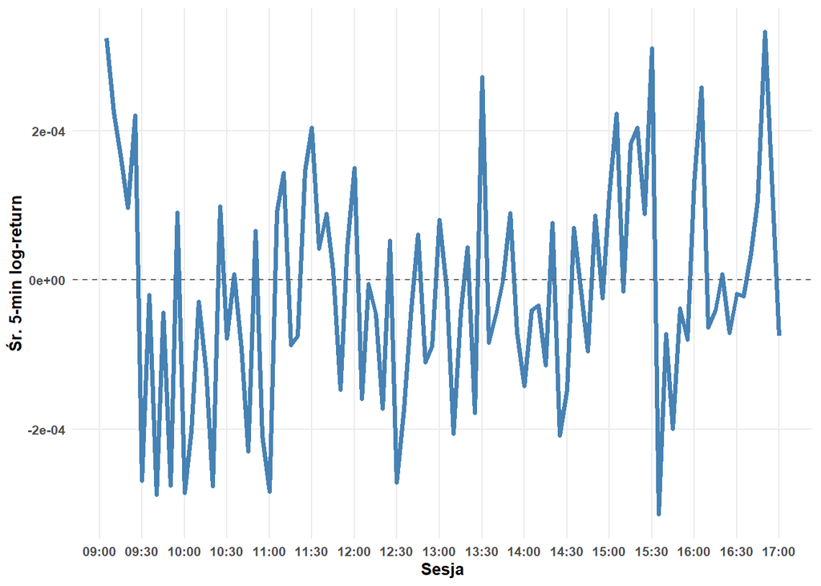

```r
cs_J$time_posix <- as.POSIXct(paste("1970-01-01", cs_J$time_in_session),format = "%Y-%m-%d %H:%M")


ggplot(cs_J, aes(x = time_posix, y = return_log)) +
  geom_line(color = "steelblue", linewidth = 1.4) +
  geom_hline(yintercept = 0, linetype = "dashed", color = "grey40") +
   scale_x_datetime(
    date_labels = "%H:%M",
    date_breaks = "30 min"
  ) +
  labs(
    x = "Sesja",
    y = "Śr. 5-min log-return"
  ) +
  theme_minimal(base_size = 10) +
  theme(
    panel.grid.minor = element_blank(),
    axis.title = element_text(face = "bold"),
    axis.text  = element_text(face = "bold")
  )
```

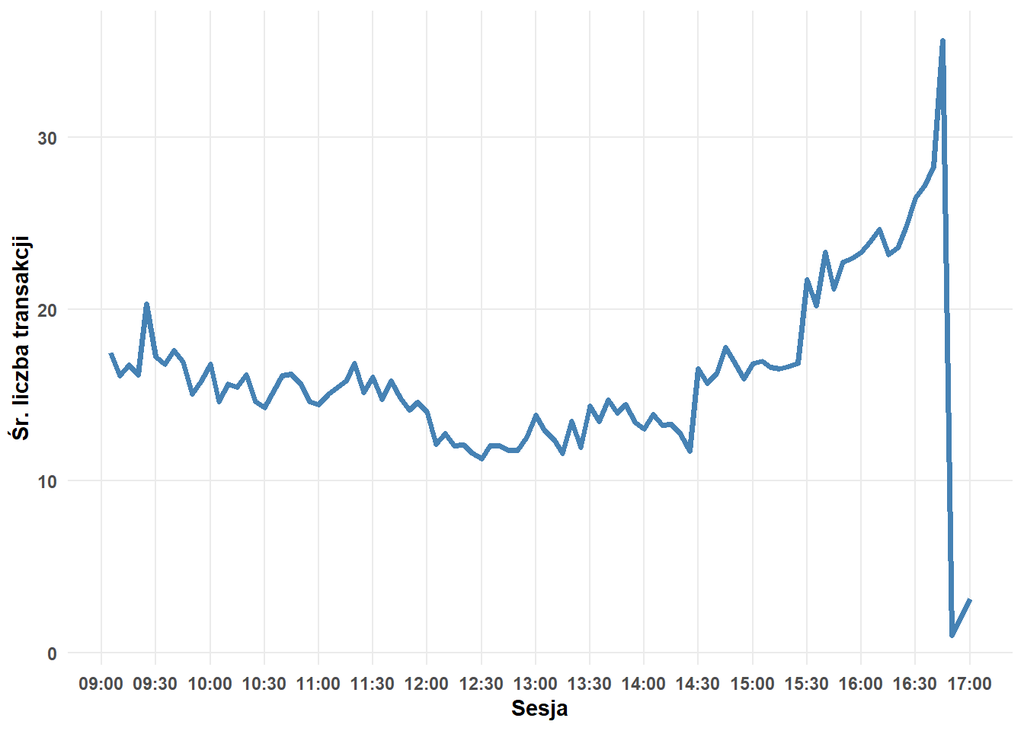

```r
ggplot(cs_J, aes(x = time_posix, y = n_trades)) +
  geom_line(color = "steelblue", linewidth = 1.4) +
  scale_x_datetime(
    date_labels = "%H:%M",
    date_breaks = "30 min"
  ) +
  labs(
    x = "Sesja",
    y = "Śr. liczba transakcji"
  ) +
  theme_minimal(base_size = 11) +
  theme(
    panel.grid.minor = element_blank(),
    axis.title = element_text(face = "bold"),
    axis.text  = element_text(face = "bold")
  )
```

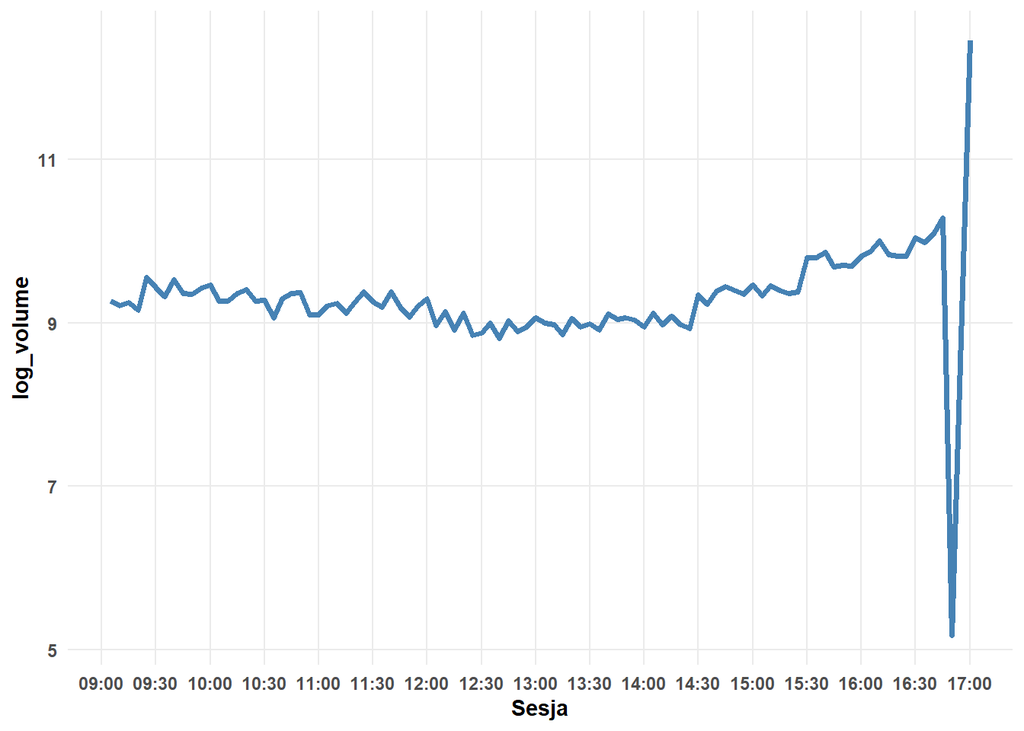

```r
ggplot(cs_J, aes(x = time_posix, y = log_volume)) +
  geom_line(color = "steelblue", linewidth = 1.4) +
  scale_x_datetime(
    date_labels = "%H:%M",
    date_breaks = "30 min"
  ) +
  labs(
    x = "Sesja",
  ) +
  theme_minimal(base_size = 11) +
  theme(
    panel.grid.minor = element_blank(),
    axis.title = element_text(face = "bold"),
    axis.text  = element_text(face = "bold")
  )
```

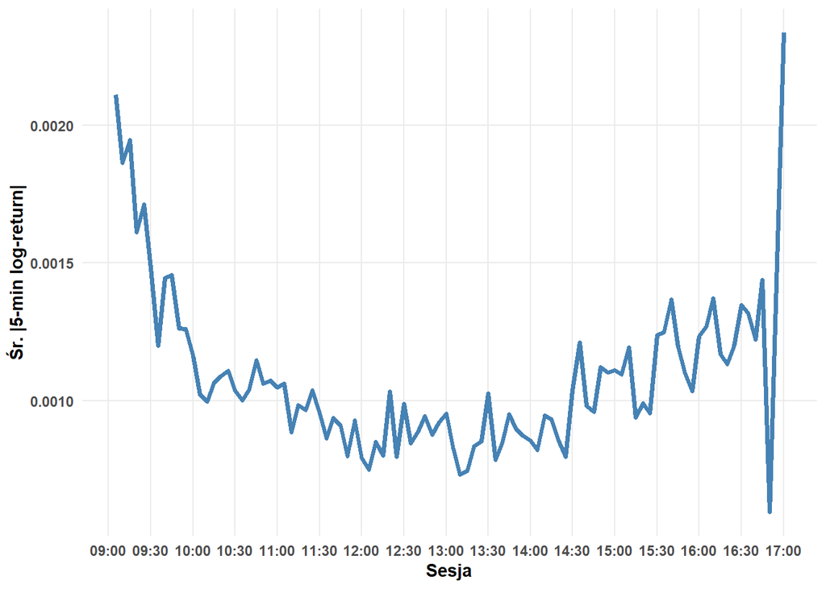

```r
cs_abs_J$time_posix <- as.POSIXct(
  paste("1970-01-01", cs_abs_J$time_in_session),
  format = "%Y-%m-%d %H:%M")


ggplot(cs_abs_J, aes(x = time_posix, y = `abs(return_log)`)) +
  geom_line(color = "steelblue", linewidth = 1.4) +
  scale_x_datetime(
    date_labels = "%H:%M",
    date_breaks = "30 min"
  ) +
  labs(
    x = "Sesja",
    y = "Śr. |5-min log-return|"
  ) +
  theme_minimal(base_size = 11) +
  theme(
    panel.grid.minor = element_blank(),
    axis.title = element_text(face = "bold"),
    axis.text  = element_text(face = "bold")
  )
```

- Podobna sytuacja co do spolki 1 pod wzgledem U-shape ksztaltu
- Co do stop zwrotu srednich sytuacja jest taka sama, wygladaja jak white noise .
- Natomiast w absolute zwortach jak i wolumenie wartosc podczas dogrywki (po wyraznym tąpnieciu przed zamknieceim) mocno odbija w gore.
- Natomiast srednia ilosc transakcji wyglada tak samo jak przy poprzedniej spolce.
- Takie mocne odbicia wolumenu przy niskiej ilosci transakcji i ujemnych stopach zwrotu moga swiadczyc o zawieraniu duzych zlecen na koniec sesji zeby np zdumpowac cene spolki i na tym zarobic, skoro srednio przez pol roku tak sie dzieje, moze nie byc to przypadkowe.

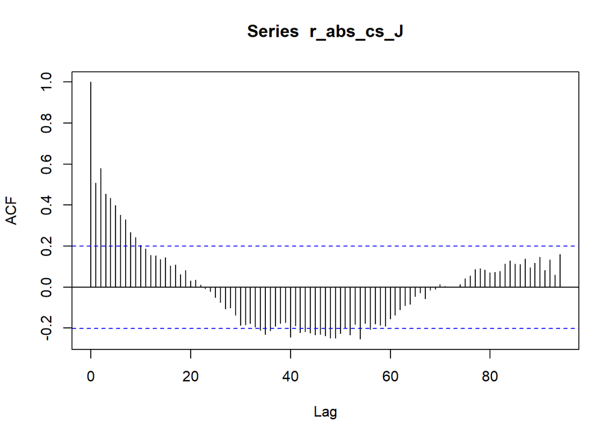

```r
r_abs_cs_J <- cs_abs_J$`abs(return_log)`[!is.na(cs_abs_J$`abs(return_log)`)]


acf_obj <- acf(r_abs_cs_J, lag.max = 300, plot = TRUE)
```

## interpretacja

- Widoczna jest wieksza sezonowość zmiennosci niż wcześniej (wieksze wartosci lagow jak i czesciej sa one statystycznie istotne), i oczywiscie sezonowosc zmiennosci wystepuje.
- Lagi okolo wartosci 50 sa statystycznie istotne , jednakze na oko nie widac nadal dlugiej pamieci.

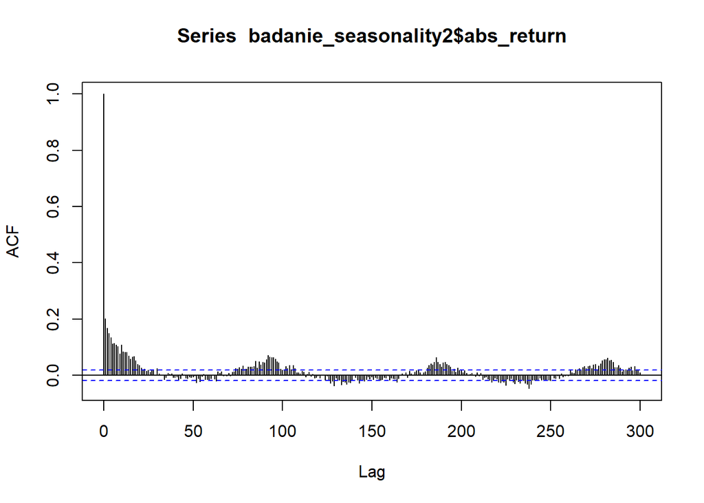

```r
badanie_seasonality2 <-  returns_5min_spolkaI

badanie_seasonality2$abs_return <- abs(badanie_seasonality2$return_log)



acf_obj3 <- acf(badanie_seasonality2$abs_return, lag.max = 300, plot = TRUE)
```

- tu dosyc ladnie widac sezonowosc zmiennosci

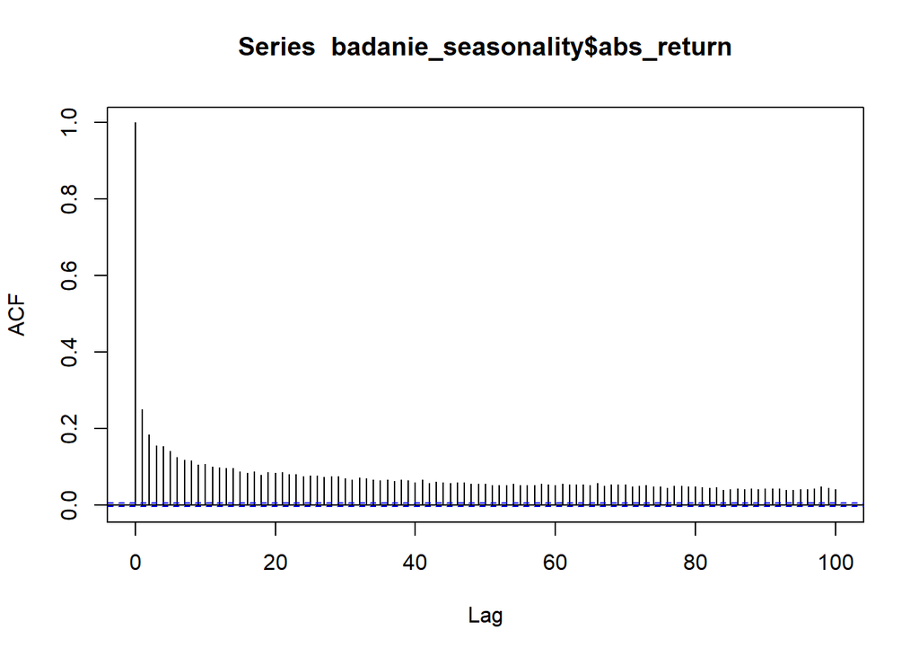

```r
badanie_seasonality <-  returns_1s_spolkaJ


badanie_seasonality$abs_return <- abs(badanie_seasonality$return)

badanie_seasonality <- badanie_seasonality[!is.na(badanie_seasonality$abs_return),]



acf_obj2 <- acf(badanie_seasonality$abs_return, lag.max = 100, plot = TRUE)
```

- A tutaj np widac wizualny mozliwy przyklad dlugiej pamieci wraz ze wzrostem lagow decay wartosci jest powolny.

# **CZESC 2 PROJEKTU**

## Elastic Fourier Form

### stopy zwrotu log do estymwowania wariancji z proby

```r
df <- returns_5min_spolkaJ %>% mutate(date = as.Date(datetime))


daily_returns <- df %>%
  group_by(date) %>%
  summarise(
    P_open  = first(price),
    P_close = last(price),
    r_daily = log(P_close) - log(P_open),
    .groups = "drop"
  )



daily_returns
```

```
# A tibble: 124 × 4
   date       P_open P_close   r_daily
   <date>      <dbl>   <dbl>     <dbl>
 1 2018-01-03   46.4    45.5 -0.0178
 2 2018-01-04   46.0    46.2  0.00643
 3 2018-01-05   46.2    46.5  0.00475
 4 2018-01-08   46.7    47.3  0.0134
 5 2018-01-09   47.3    47.2 -0.000130
 6 2018-01-10   47.0    47.0 -0.00192
 7 2018-01-11   46.9    47.7  0.0166
 8 2018-01-12   47.7    47.7 -0.000419
 9 2018-01-15   47.8    47.7 -0.00189
10 2018-01-16   47.7    48.7  0.0203
# ℹ 114 more rows
```

### estymowanie wariancji z proby

```r
sigma2_hat <- var(daily_returns$r_daily)
sigma2_hat
```

```
[1] 0.0002185015
```

### przygotowanie zmiennych do estymacji FFF

```r
# dodajmey dzien tygodnia do danych indeks D

df <- returns_5min_spolkaJ %>%
  mutate(
    date = as.Date(datetime),
    wday = wday(datetime, label = TRUE),
  ) %>%
  group_by(date) %>% mutate(d = row_number())


D <- max(df$d)

rbar <- mean(df$return_log)

# zmiennna y
df <- df %>%
  mutate( y = 2 * log(abs(return_log - rbar) / (sqrt(sigma2_hat) / sqrt(D))) )


# prawa strona trend liniowy i kwadratowy, pozniej juz w funkcji fitowania FFF bedziemy dodawac sinusy i cosinusy


df <- df %>% mutate(d1 = d / mean(1:D),d2 = (d^2) / mean((1:D)^2))
```

### funkcja do fitowania FFF

- jako zmienne binarne dodajemy same dni tygodnia bez uwzgledniania konkretnych dat w ciagu badanego okresu np danych makro etc.
- z dniami tygodnai zrobilismy nastepująco : funkcja lm pomija pierwszy dzien (poniedzialek) a reszte doklada jako dummy variables.
- poniewaz zmienna wday jest typem factor
- Nie sprawdzamy dodatkowo wszystkich kombinacji (np wyrzucajac wtorek ,srode etc) poniewaz zmienne binarne tylko lekko podwyzsza nam dopasowanie funkcji FFF,zatem nie maja drastycznego wplywu na dopasowanie modelu.
- nie mozemy wszystkich naraz dodac do modelu poniewaz wtedy bedziemy miec perfect multicollinearity, podobnie jak z danymi ekonomicznymi jesli sa kwartaly.
- Mozna byloby oszacowac regresje z metoda Newey-West (estymacja SE modelu bez autocorrelation i heteroscedasticity ) , jednak przy okolo 12 tys danych nie bedize mialo to drastycznego wplywu na wyniki.

```r
df$wday <- factor(df$wday, ordered = FALSE)
```

```r
df
```

```
# A tibble: 11,595 × 9
# Groups:   date [124]
   datetime            price return_log date       wday        d      y     d1
   <dttm>              <dbl>      <dbl> <date>     <fct>   <int>  <dbl>  <dbl>
 1 2018-01-03 09:05:00  46.4 -0.000431  2018-01-03 "śr\\."     1 -2.61  0.0208
 2 2018-01-03 09:10:00  46.0 -0.00671   2018-01-03 "śr\\."     2  2.97  0.0417
 3 2018-01-03 09:15:00  45.9 -0.00370   2018-01-03 "śr\\."     3  1.77  0.0625
 4 2018-01-03 09:20:00  46.0  0.00196   2018-01-03 "śr\\."     4  0.532 0.0833
 5 2018-01-03 09:25:00  46.0  0.000218  2018-01-03 "śr\\."     5 -3.71  0.104
 6 2018-01-03 09:30:00  46.0 -0.000653  2018-01-03 "śr\\."     6 -1.75  0.125
 7 2018-01-03 09:35:00  46.0  0.00196   2018-01-03 "śr\\."     7  0.529 0.146
 8 2018-01-03 09:45:00  46   -0.000869  2018-01-03 "śr\\."     8 -1.16  0.167
 9 2018-01-03 09:50:00  45.9 -0.00131   2018-01-03 "śr\\."     9 -0.330 0.188
10 2018-01-03 09:55:00  45.9  0.0000461 2018-01-03 "śr\\."    10 -6.29  0.208
# ℹ 11,585 more rows
# ℹ 1 more variable: d2 <dbl>
```

```r
fit_FFF <- function(P, data, D, with_dummies = FALSE) {
  # bedziemy sprawdzac funkcja lapply jakie dobierac ilosc par sin i cos
  # a takze to czy w modelu uzyc zmiennych binarnych czy nie


  X <- data

  # liczenie cos i sin i dodanie ich do glownego df
  for (p in 1:P) {
    X[[paste0("cos", p)]] <- cos(2*pi*p*X$d / D) #
    X[[paste0("sin", p)]] <- sin(2*pi*p*X$d / D)
  }

  rhs <- c("d1", "d2",paste0("cos", 1:P), paste0("sin", 1:P)) #prawa strona regresji sin cos trend liniwoy i kwadratowy

  if (with_dummies) { # zmienne binarne w modelu w zaleznosci od parametru
    rhs <- c(rhs, "wday")  # to ew do zmieany
  }

  fml <- as.formula(paste("y ~", paste(rhs, collapse = " + ")))  # budowa modelu

  # fit modelu
  lm(fml, data = X)
}
```

### model bez binary variables

- sprawdzenie ilu par sinusow i cosinusow potrzebujemy
- generalnie wybieramy bardziej konserwatywne kryterium informacyjne ( BIC) do wyboru modelu, jednakze zostawiamy obliczenia dla aic.

```r
models_no_dummy <- lapply(1:10, fit_FFF, # sprawdzamy dla od 1 od 10 par sinusow i cosinusow
                          data = df, D = D, with_dummies = FALSE)

bic_no <- sapply(models_no_dummy, BIC)
aic_no <- sapply(models_no_dummy, AIC)

P_no <- which.min(bic_no) # wybor min bic

bic_no
```

```
 [1] 56009.34 56021.68 56032.38 56047.71 56061.41 56079.15 56095.18 56109.61
 [9] 56127.96 56144.23
```

```r
aic_no
```

```
 [1] 55965.19 55962.81 55958.80 55959.41 55958.39 55961.41 55962.73 55962.44
 [9] 55966.08 55967.63
```

```r
P_no
```

```
[1] 1
```

- zatem wybieramy model z jedna para sin i cos w modelu bez zmiennych binarnych

### model z binary variables

```r
models_dummy <- lapply(1:10, fit_FFF, # to samo tutaj jednakze zakladamy model z dummy variables
                       data = df, D = D, with_dummies = TRUE)

bic_d <- sapply(models_dummy, BIC)
aic_d <- sapply(models_dummy, AIC)

bic_d
```

```
 [1] 56043.21 56055.56 56066.31 56081.61 56095.34 56113.09 56129.14 56143.56
 [9] 56161.91 56178.19
```

```r
aic_d
```

```
 [1] 55969.63 55967.26 55963.29 55963.87 55962.89 55965.92 55967.25 55966.96
 [9] 55970.60 55972.16
```

```r
P_d <- which.min(bic_d)

AIC_dd <- which.min(aic_d)

AIC_dd
```

```
[1] 5
```

```r
P_d
```

```
[1] 1
```

- generalnie dobor zmiennych pogarsza BIC, zateem finalny model bedzie bez dummy variables
- jest rozbieznosc poniewaz aic pokazauje nam uzycie 5 par sin i cos z dummy var i bez
- przyjmujemy jak pisalismy wyzej BIC, poniewaz AIC jest podane na overfit dlatego ze ma mniejsze penalty do log-likelihoodu ma tendecje do wskazywania modeli ktore overfituja jako lepsze.

### wybor finalnego modelu i podsumowanie

```r
final_model <- models_no_dummy[[P_no]] #  P_no


summary(final_model)
```

```
Call:
lm(formula = fml, data = X)

Residuals:
     Min       1Q   Median       3Q      Max
-13.2530  -1.2865   0.5758   1.8540   6.2001

Coefficients:
            Estimate Std. Error t value Pr(>|t|)
(Intercept) -0.49263    0.22897  -2.151   0.0315 *
d1          -3.78019    0.65921  -5.734 1.00e-08 ***
d2           2.40254    0.44067   5.452 5.08e-08 ***
cos1        -0.08523    0.13423  -0.635   0.5255
sin1        -0.16425    0.05823  -2.821   0.0048 **
---
Signif. codes:  0 '***' 0.001 '**' 0.01 '*' 0.05 '.' 0.1 ' ' 1

Residual standard error: 2.702 on 11590 degrees of freedom
Multiple R-squared:  0.0286,    Adjusted R-squared:  0.02827
F-statistic: 85.32 on 4 and 11590 DF,  p-value: < 2.2e-16
```

- wiekszosc zmiennych jest statystycznie istotna oprocz cosinusa , co jest lepszym wynikiem niz model ponizej poniewaz nie dodajemy zbyt duzej ilosci niepotrzebnych zmiennych powodujac overfit

### wzięcie dopasownych wartosci i ich normalizacja

```r
df$f_hat <- fitted(final_model)

tmp <- exp(df$f_hat / 2)

# normalizacja
df$s_hat <- (nrow(df) * tmp) / sum(tmp)

# usuwnaie sezonowosci
df$return_deseas <- df$return_log / df$s_hat


# moduly stop zwrotu do wykresow

df$abs_before <- abs(df$return_log)
df$abs_after  <- abs(df$return_deseas)



cross_mean <- df %>%
  group_by(d) %>%
  summarise(
    abs_before = mean(abs_before),
    abs_after  = mean(abs_after),
    .groups = "drop"
  ) %>%
  pivot_longer(cols = c(abs_before, abs_after),
                      names_to = "series",
                      values_to = "mean_abs")
```

### WYKRESY

#### przekrojowe srednie

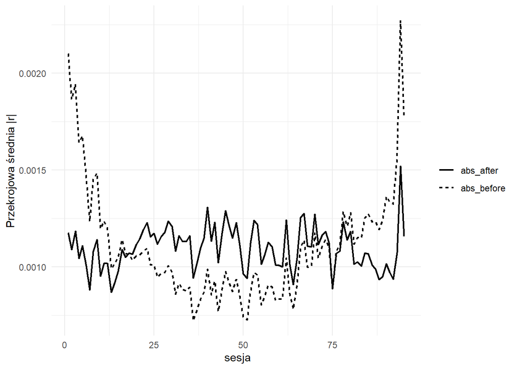

```r
ggplot(cross_mean, aes(x = d, y = mean_abs, linetype = series)) +
  geom_line(linewidth = 0.8) +
  labs(x = "  sesja ",
       y = "Przekrojowa średnia |r|",
       linetype = "") +
  theme_minimal()
```

- usunelo ksztalt U z abs stop

#### autokorelacja usunieta z szeregu

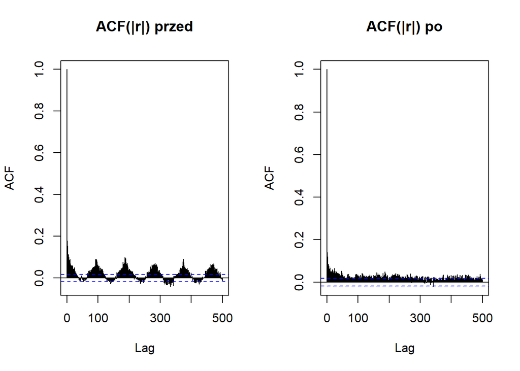

```r
par(mfrow = c(1, 2))

acf(df$abs_before, lag.max = 500, na.action = na.pass, main = "ACF(|r|) przed")
acf(df$abs_after,  lag.max = 500, na.action = na.pass, main = "ACF(|r|) po")
```

- poprawnie usunelismy sezonowosc z danych, ale nadal mamy dluga pamiec.

#### sroddzienna skladowa

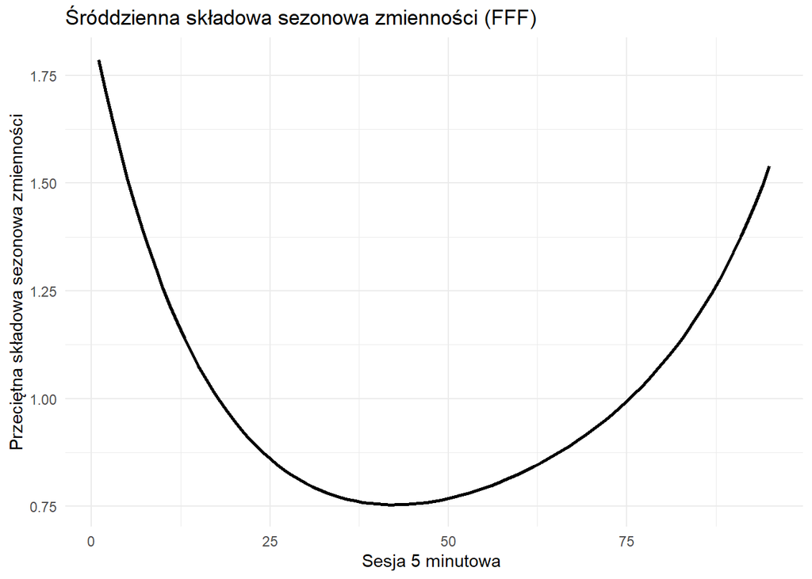

```r
season_mean <- df %>%
  group_by(d) %>%
  summarise(
    s_mean = mean(s_hat),

  )

ggplot(season_mean, aes(x = d, y = s_mean)) +
  geom_line(linewidth = 0.9) +
  labs(
    x = "Sesja 5 minutowa ",
    y = "Przeciętna składowa sezonowa zmienności",
    title = "Śróddzienna składowa sezonowa zmienności (FFF)"
  ) +
  theme_minimal()
```

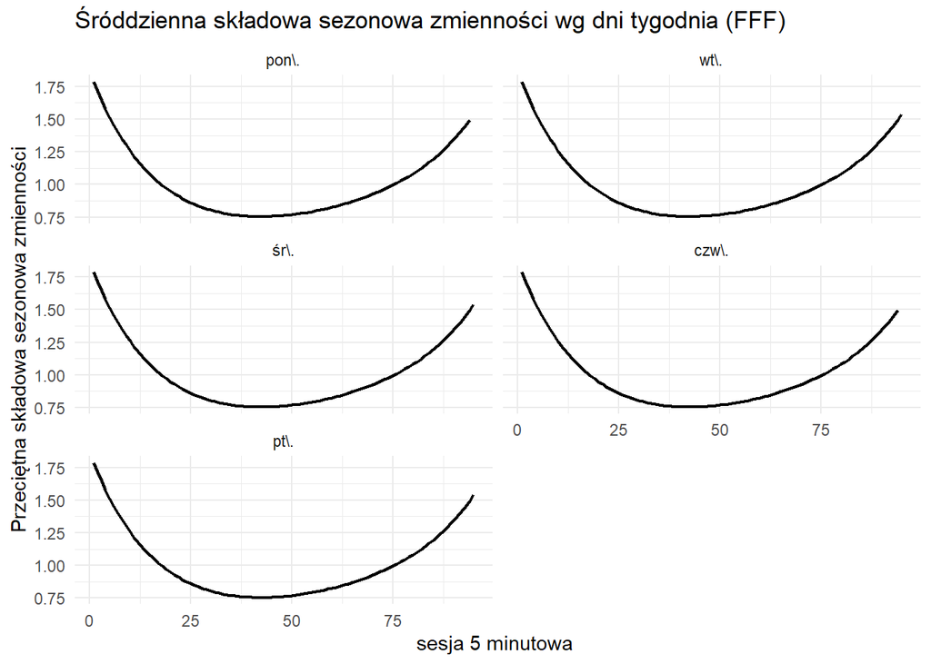

```r
season_mean_wday <- df %>%
  group_by(wday, d) %>%
  summarise(
    s_mean = mean(s_hat),
    .groups = "drop" # zeby nie dostac errora
  )

ggplot(season_mean_wday, aes(x = d, y = s_mean)) +
  geom_line(linewidth = 0.8) +
  facet_wrap(~ wday, ncol = 2) +
  labs(
    x = "sesja 5 minutowa ",
    y = "Przeciętna składowa sezonowa zmienności",
    title = "Śróddzienna składowa sezonowa zmienności wg dni tygodnia (FFF)"
  ) +
  theme_minimal()
```

### kryterium AIC

- Wybieramy model bez zmiennych binarnych poniewaz ma mniejsze AIC

```r
final_model <- models_no_dummy[[which.min(aic_no)]] #  P_no


summary(final_model)
```

```
Call:
lm(formula = fml, data = X)

Residuals:
     Min       1Q   Median       3Q      Max
-13.3070  -1.2552   0.5824   1.8504   6.0541

Coefficients:
              Estimate Std. Error t value Pr(>|t|)
(Intercept)   2.373043   1.611792   1.472  0.14097
d1          -12.579181   4.872990  -2.581  0.00985 **
d2            8.342080   3.268893   2.552  0.01072 *
cos1         -1.852007   0.974339  -1.901  0.05736 .
cos2         -0.469746   0.242745  -1.935  0.05300 .
cos3         -0.181364   0.110219  -1.645  0.09990 .
cos4          0.005904   0.067047   0.088  0.92984
cos5         -0.068165   0.049832  -1.368  0.17137
sin1         -0.124295   0.105851  -1.174  0.24032
sin2         -0.014761   0.060904  -0.242  0.80850
sin3          0.072504   0.048196   1.504  0.13251
sin4         -0.038138   0.042882  -0.889  0.37383
sin5          0.071549   0.040199   1.780  0.07513 .
---
Signif. codes:  0 '***' 0.001 '**' 0.01 '*' 0.05 '.' 0.1 ' ' 1

Residual standard error: 2.701 on 11582 degrees of freedom
Multiple R-squared:  0.03051,   Adjusted R-squared:  0.02951
F-statistic: 30.37 on 12 and 11582 DF,  p-value: < 2.2e-16
```

- duzo sin i cos jest tutaj nieistotnych statycznie p-value > 0.05 (przyjmujac 5% siginif level ), wychodzi na to ze tylko dwa paramy sa istotne statystycznie 2 sa na granicy reszta nie jest , co kieruje nas do odpowiedzi ze model wybrany na podstawie BIC jest lepszy, bo obceny wprowadza za duzo niepotrzebnych zmiennych, co tez BIC nam pokazalo.

#### wykresy

```r
df$f_hat <- fitted(final_model)

tmp <- exp(df$f_hat / 2)

# normalizacja
df$s_hat <- (nrow(df) * tmp) / sum(tmp) # nrow Liczba dni * liczba binow w dniu D (T*D)

# usuwnaie sezonowosci
df$return_deseas <- df$return_log / df$s_hat


# moduly stop zwrotu do wykresow

df$abs_before <- abs(df$return_log)
df$abs_after  <- abs(df$return_deseas)



cross_mean <- df %>%
  group_by(d) %>%
  summarise(
    abs_before = mean(abs_before),
    abs_after  = mean(abs_after),
    .groups = "drop"
  ) %>%
  pivot_longer(cols = c(abs_before, abs_after),
                      names_to = "series",
                      values_to = "mean_abs")
```

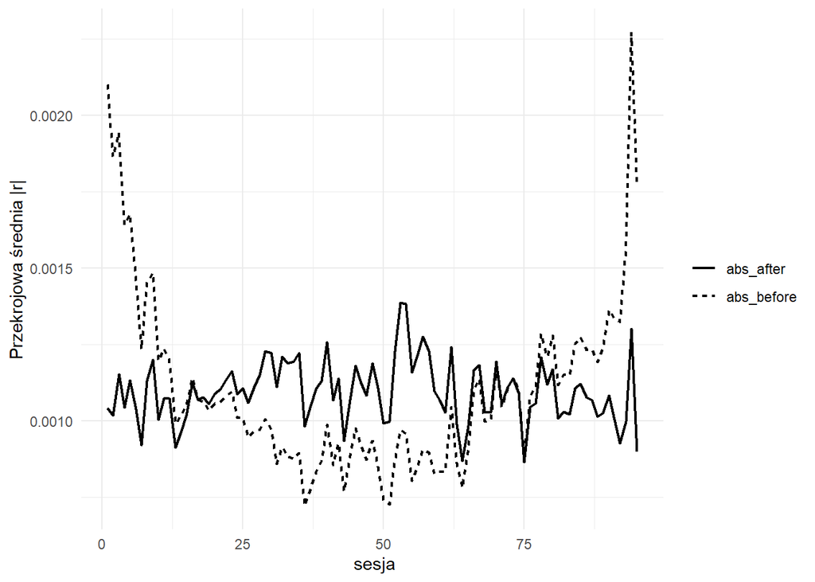

```r
ggplot(cross_mean, aes(x = d, y = mean_abs, linetype = series)) +
  geom_line(linewidth = 0.8) +
  labs(x = "  sesja ",
       y = "Przekrojowa średnia |r|",
       linetype = "") +
  theme_minimal()
```

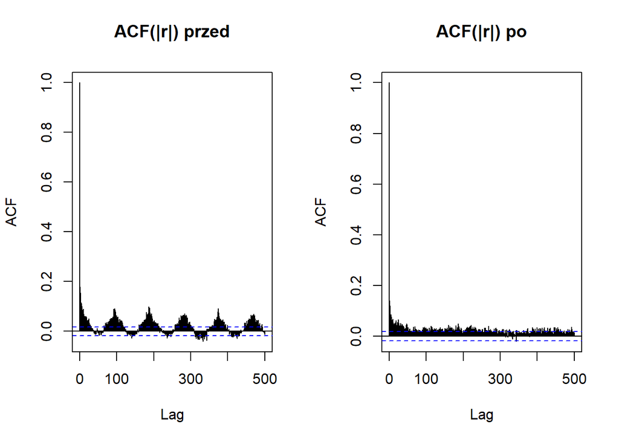

```r
par(mfrow = c(1, 2))

acf(df$abs_before, lag.max = 500, na.action = na.pass, main = "ACF(|r|) przed")
acf(df$abs_after,  lag.max = 500, na.action = na.pass, main = "ACF(|r|) po")
```

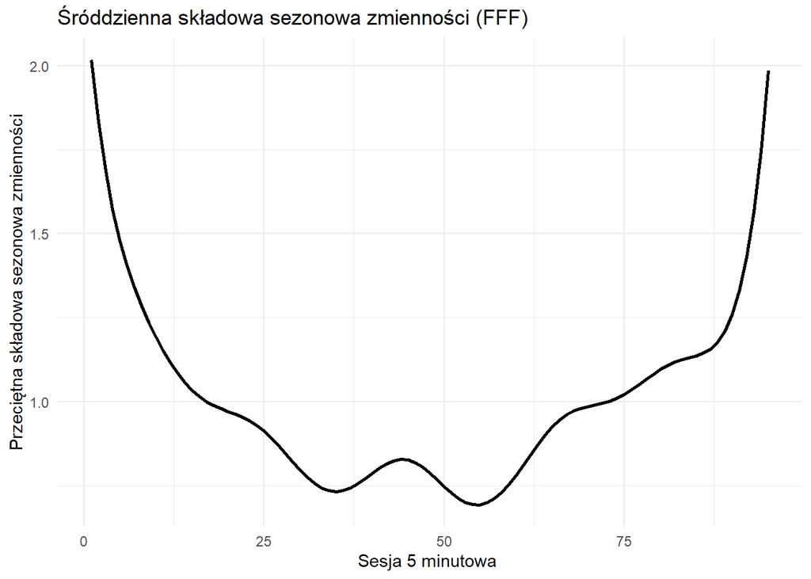

```r
season_mean <- df %>%
  group_by(d) %>%
  summarise(
    s_mean = mean(s_hat),

  )

ggplot(season_mean, aes(x = d, y = s_mean)) +
  geom_line(linewidth = 0.9) +
  labs(
    x = "Sesja 5 minutowa ",
    y = "Przeciętna składowa sezonowa zmienności",
    title = "Śróddzienna składowa sezonowa zmienności (FFF)"
  ) +
  theme_minimal()
```

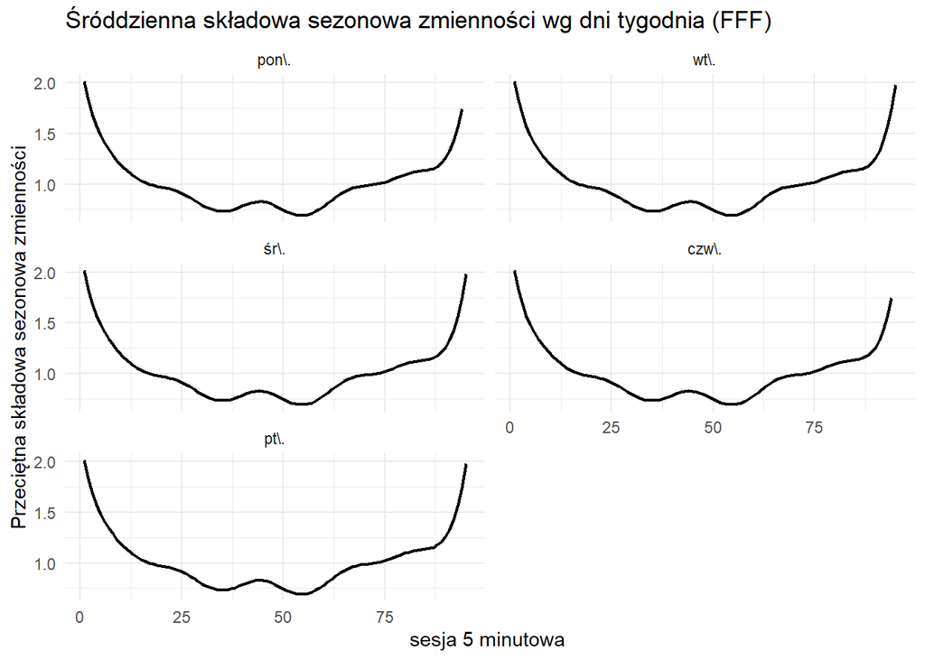

```r
season_mean_wday <- df %>%
  group_by(wday, d) %>%
  summarise(
    s_mean = mean(s_hat),
    .groups = "drop" # zeby nie dostac errora
  )

ggplot(season_mean_wday, aes(x = d, y = s_mean)) +
  geom_line(linewidth = 0.8) +
  facet_wrap(~ wday, ncol = 2) +
  labs(
    x = "sesja 5 minutowa ",
    y = "Przeciętna składowa sezonowa zmienności",
    title = "Śróddzienna składowa sezonowa zmienności wg dni tygodnia (FFF)"
  ) +
  theme_minimal()
```

- AIC wskazal nam model z wieksza iloscia par sin i cos , co przejawia sie w mniej gladkiej srodziennej skladowej sezonowosci i dlatego widzimy te “gorki” na dwoch ostatnich wykresach.. Przekrojowa srednia |r| stop zwrotu jak i w acf na nich daje nam niemalze identyczne wyniki co poprzednio, usunelismy sezonowosc z danych zostala dluga pamiec i usnuelismy U-shape z |r| zwrotow.

# Model multiplikatywny engle’a i sokalskiej

```r
head(returns_5min_spolkaI)
```

```
             datetime  price    return_log
2 2018-01-03 09:05:00 102.90  0.0092751458
3 2018-01-03 09:10:00 102.90  0.0000000000
4 2018-01-03 09:15:00 102.60 -0.0029197101
5 2018-01-03 09:20:00 102.70  0.0009741842
6 2018-01-03 09:25:00 102.95  0.0024313165
7 2018-01-03 09:30:00 102.90 -0.0004857906
```

## liczenie log dziennych stop zwrotu i fit arma-garch modelu

- wybralismy lagi dla garch klasycznie (1,1)
- dla army przyjmujemy heurstycznie lag (1,1) bez dokaldnego identyfikowania orderu.
- Zakladamy tez rozklad skosny t-studenta poniewaz kurtoza jest w obu spolkach bardzo wysoka jak i zakladam ze modelowanei skosnosci rozkladu moze pomoc lepiej rozklad dopasowac.

```r
daily <- df %>%
  group_by(date) %>%
  summarise( p_open  = first(price),
             p_close = last(price),
             r_day   = log(p_close) - log(p_open),
  )

spec <- ugarchspec(
  variance.model = list(model = "sGARCH", garchOrder = c(1, 1)),
  mean.model     = list(armaOrder = c(1, 1), include.mean = TRUE),
  distribution.model = "sstd" # norm
)

fit <- ugarchfit(spec = spec, data = daily$r_day)


# wyestymowana wariancja
daily$sigma2_hat <- as.numeric(sigma(fit))^2
```

```r
infocriteria(fit)
```

```
Akaike       -5.536568
Bayes        -5.354615
Shibata      -5.544240
Hannan-Quinn -5.462654
```

```r
fit@fit$matcoef
```

```
            Estimate  Std. Error  t value Pr(>|t|)
mu     -2.237280e-03          NA       NA       NA
ar1     8.848185e-01          NA       NA       NA
ma1    -1.000000e+00          NA       NA       NA
omega   1.946583e-07          NA       NA       NA
alpha1  3.111073e-10          NA       NA       NA
beta1   9.989999e-01          NA       NA       NA
skew    8.747196e-01          NA       NA       NA
shape   5.999916e+01          NA       NA       NA
```

```r
daily
```

```
# A tibble: 124 × 5
   date       p_open p_close     r_day sigma2_hat
   <date>      <dbl>   <dbl>     <dbl>      <dbl>
 1 2018-01-03   46.4    45.5 -0.0178     0.000205
 2 2018-01-04   46.0    46.2  0.00643    0.000205
 3 2018-01-05   46.2    46.5  0.00475    0.000205
 4 2018-01-08   46.7    47.3  0.0134     0.000205
 5 2018-01-09   47.3    47.2 -0.000130   0.000205
 6 2018-01-10   47.0    47.0 -0.00192    0.000205
 7 2018-01-11   46.9    47.7  0.0166     0.000205
 8 2018-01-12   47.7    47.7 -0.000419   0.000205
 9 2018-01-15   47.8    47.7 -0.00189    0.000205
10 2018-01-16   47.7    48.7  0.0203     0.000204
# ℹ 114 more rows
```

```r
df <- df %>%
  left_join(daily %>% select(date, sigma2_hat), by = "date") %>%
  filter(!is.na(return_log), !is.na(sigma2_hat), sigma2_hat > 0)
```

```r
df
```

```
# A tibble: 11,595 × 15
# Groups:   date [124]
   datetime            price return_log date       wday        d      y     d1
   <dttm>              <dbl>      <dbl> <date>     <fct>   <int>  <dbl>  <dbl>
 1 2018-01-03 09:05:00  46.4 -0.000431  2018-01-03 "śr\\."     1 -2.61  0.0208
 2 2018-01-03 09:10:00  46.0 -0.00671   2018-01-03 "śr\\."     2  2.97  0.0417
 3 2018-01-03 09:15:00  45.9 -0.00370   2018-01-03 "śr\\."     3  1.77  0.0625
 4 2018-01-03 09:20:00  46.0  0.00196   2018-01-03 "śr\\."     4  0.532 0.0833
 5 2018-01-03 09:25:00  46.0  0.000218  2018-01-03 "śr\\."     5 -3.71  0.104
 6 2018-01-03 09:30:00  46.0 -0.000653  2018-01-03 "śr\\."     6 -1.75  0.125
 7 2018-01-03 09:35:00  46.0  0.00196   2018-01-03 "śr\\."     7  0.529 0.146
 8 2018-01-03 09:45:00  46   -0.000869  2018-01-03 "śr\\."     8 -1.16  0.167
 9 2018-01-03 09:50:00  45.9 -0.00131   2018-01-03 "śr\\."     9 -0.330 0.188
10 2018-01-03 09:55:00  45.9  0.0000461 2018-01-03 "śr\\."    10 -6.29  0.208
# ℹ 11,585 more rows
# ℹ 7 more variables: d2 <dbl>, f_hat <dbl>, s_hat <dbl>, return_deseas <dbl>,
#   abs_before <dbl>, abs_after <dbl>, sigma2_hat <dbl>
```

## estymator srodzdziennej sezonowosci

- liczymy jako E(r_log^2/sigma)

```r
s2_hat_d <- df %>% group_by(d) %>% summarise( s2_hat = mean(return_log^2 / sigma2_hat) )
```

## normalizacja

- Dlaczego ?
- aby opisywała wyłącznie względne różnice zmienności w ciągu dnia, a nie jej poziom.
- To tez daje nam interpretacja jak w FFF czyli powyzej 1 bedzie ze zmiennosc jest powyzej sredniej a ponizej 1 to bedzie ponizej sredniej.

```r
s2_hat_d <- s2_hat_d %>% mutate( s_hat_raw = sqrt(s2_hat), s_hat = s_hat_raw / mean(s_hat_raw)) %>% select(d, s_hat)
```

## wykresy

```r
df
```

```
# A tibble: 11,595 × 15
# Groups:   date [124]
   datetime            price return_log date       wday        d      y     d1
   <dttm>              <dbl>      <dbl> <date>     <fct>   <int>  <dbl>  <dbl>
 1 2018-01-03 09:05:00  46.4 -0.000431  2018-01-03 "śr\\."     1 -2.61  0.0208
 2 2018-01-03 09:10:00  46.0 -0.00671   2018-01-03 "śr\\."     2  2.97  0.0417
 3 2018-01-03 09:15:00  45.9 -0.00370   2018-01-03 "śr\\."     3  1.77  0.0625
 4 2018-01-03 09:20:00  46.0  0.00196   2018-01-03 "śr\\."     4  0.532 0.0833
 5 2018-01-03 09:25:00  46.0  0.000218  2018-01-03 "śr\\."     5 -3.71  0.104
 6 2018-01-03 09:30:00  46.0 -0.000653  2018-01-03 "śr\\."     6 -1.75  0.125
 7 2018-01-03 09:35:00  46.0  0.00196   2018-01-03 "śr\\."     7  0.529 0.146
 8 2018-01-03 09:45:00  46   -0.000869  2018-01-03 "śr\\."     8 -1.16  0.167
 9 2018-01-03 09:50:00  45.9 -0.00131   2018-01-03 "śr\\."     9 -0.330 0.188
10 2018-01-03 09:55:00  45.9  0.0000461 2018-01-03 "śr\\."    10 -6.29  0.208
# ℹ 11,585 more rows
# ℹ 7 more variables: d2 <dbl>, f_hat <dbl>, s_hat <dbl>, return_deseas <dbl>,
#   abs_before <dbl>, abs_after <dbl>, sigma2_hat <dbl>
```

### usuniecie sezonowosci z 5-minutowych zwrotow

- liczenie stop abs przed i po usuniecie od wykresu

```r
df <- df %>% mutate( return_deseas = return_log / s_hat, abs_before = abs(return_log), abs_after  = abs(return_deseas) )
```

```r
str(s2_hat_d)
```

```
tibble [95 × 2] (S3: tbl_df/tbl/data.frame)
 $ d    : int [1:95] 1 2 3 4 5 6 7 8 9 10 ...
 $ s_hat: num [1:95] 1.77 1.63 1.81 1.52 1.51 ...
```

```r
class(df)
```

```
[1] "grouped_df" "tbl_df"     "tbl"        "data.frame"
```

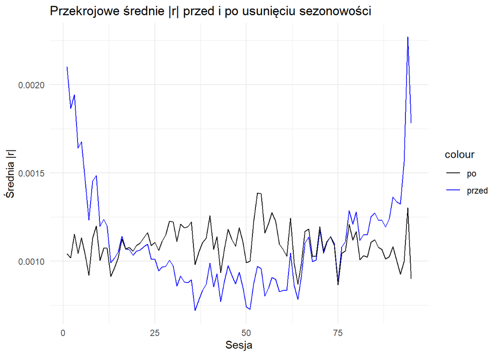

```r
cross_mean <- df %>%group_by(d) %>%
  summarise( before = mean(abs_before), after  = mean(abs_after) )

ggplot(cross_mean, aes(x = d)) +
  geom_line(aes(y = before, colour = "przed")) +
  geom_line(aes(y = after,  colour = "po")) +
  labs( x = "Sesja", y = "Średnia |r|", title = "Przekrojowe średnie |r| przed i po usunięciu sezonowości") +
  scale_colour_manual(values = c("black", "blue")) +
  theme_minimal()
```

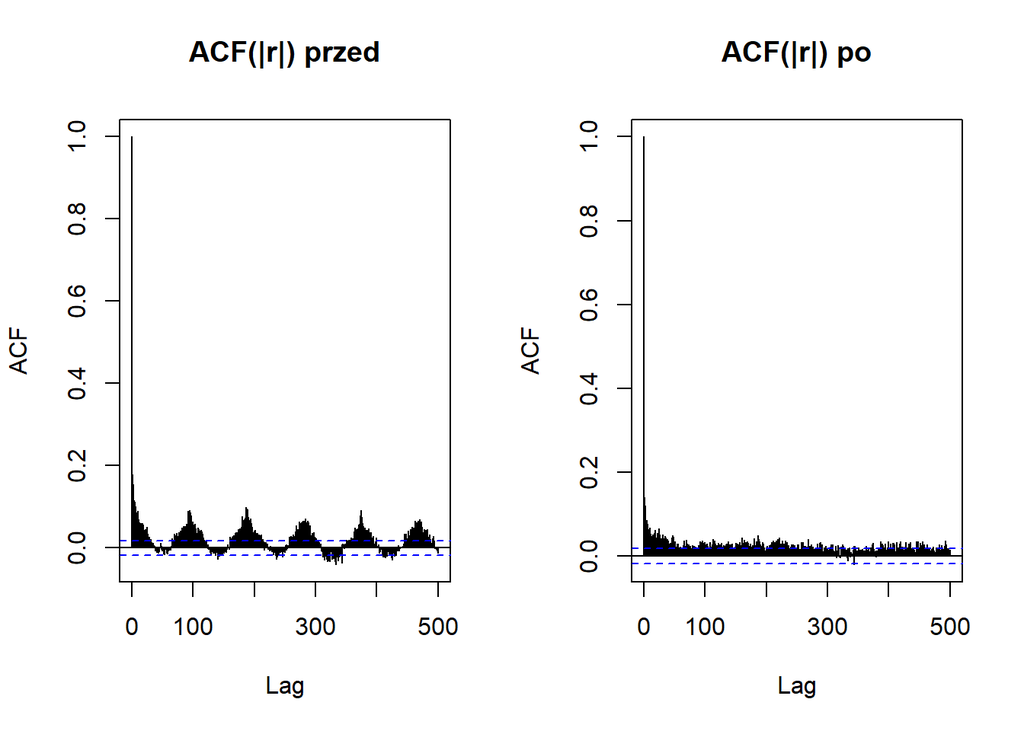

```r
par(mfrow = c(1, 2))
acf(df$abs_before, lag.max = 500, main = "ACF(|r|) przed")
acf(df$abs_after,  lag.max = 500, main = "ACF(|r|) po")
```

### przecietne wartosci skladowej sezonowej srodziennej zmiennosci

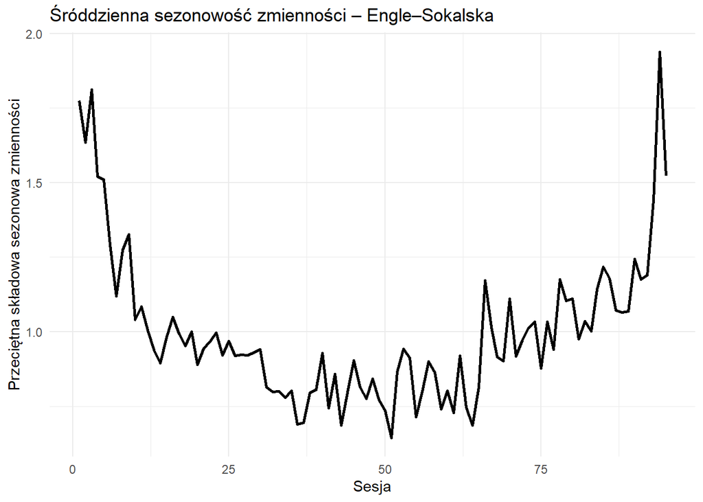

```r
ggplot(s2_hat_d, aes(x = d, y = s_hat)) +
  geom_line(linewidth = 1) +
  labs(
    x = "Sesja",
    y = "Przeciętna składowa sezonowa zmienności",
    title = "Śróddzienna sezonowość zmienności – Engle–Sokalska"
  ) +
  theme_minimal()
```

- typowy U-shape poczatek i koniec sesji sezonowosc jest powyzej sredniej natomiast w polowie jest ponizej sredniej.